# Lab 3: Mine Crafting

As with previous labs, be sure to submit only the `lab3.ipynb` and `lab3.html` version of the lab in your github `Lab3` folder. No more, and no less.

## Introduction

Imagine you are a scientist for a mining company that operates a vertical mine at the Earth's equator. This is one of the deepest mines on Earth; it's roughly 4 km to the bottom of the shaft. Your boss proposes to measure the vertical depth of the shaft by dropping a 1 kg test mass and accurately measuring the time to hit the bottom.

You will be guided in your investigations below and submit your report in the form of this notebook. Be sure to be quantitative in nature, produce highly polished plots, with appropriate titles, units, etc.

A table of relevant physical constants is below. Good luck!

| Quantity | Value |
| --- | --- |
| Gravitational Constant ($G$) | $6.6743 \times 10^{-11}$ m$^3$/kg/s$^2$ |
| Gravitational Acceleration ($g_o$) | 9.81 m/s$^2$ (approximate) |
| Mass of the Earth ($M_{\oplus}$) | $5.972 \times 10^{24}$ kg |
| Mass of the Moon ($M_{m}$) | $7.35 \times 10^{22}$ kg |
| Radius of the Earth ($R_{\oplus}$) | 6378.1 km |
| Radius of the Moon ($R_{m}$) | 1738.1 km |
| Earth's Rotation Rate at the Equator | $7.272 \times 10^{-5} $ rad/s |

```python
# Initialize constant variables
G = 6.6743 * (10**-11)    # Gravitational Constant (m^3 kg^-1 s^-2)
g_0 = 9.81    # Gravitational Acceleration (m s^-2)
M_E = 5.972 * (10**24)    # Mass of the Earth (kg)
M_m = 7.35 * (10**22)    # Mass of the Moon (kg)
R_E = 6378.1 * (10**3)    # Radius of the Earth (m)
R_m = 1738.1 * (10**3)    # Radius of the Moon (m)
rot_rate_E = 7.272 * (10**-5)    # Earth's Rotation Rate at the Equator (rad s^-1)


# Import necessary libraries
import numpy as np
import matplotlib.pyplot as plt
from scipy.integrate import solve_ivp
```

## Part 1: The Ideal Case

In this section and the following sections, we calculate the time for the 1 kg test mass to reach the bottom of the mineshaft under a series of increasingly complex assumptions. Remember that a projectile experiencing a constant gravitational force, plus a drag force, obeys the following second order differential equation:

$$ \frac{d^2y}{dt^2} = -g + \alpha \left| \frac{dy}{dt} \right|^{\gamma} \tag{1} $$

where $t$ is time, $y$ is the height, $g$ is the gravitational acceleration, $\alpha$ is the drag coefficient, and $\gamma$ is the speed dependence of the drag. For example, for $\gamma=2$, the drag force grows proportionally to the speed *squared*. **Hint**: pay particular attention to the sign conventions in your implementation! The drag, by definition, should *oppose* the direction of motion.

1. First, make a simple calculation of how long a test mass would take to reach the bottom of the 4km shaft assuming no drag. This is the simple free-fall algebraic expression you know from PHYS 171.
2. Next, reduce (1) into a *system* of coupled first order differential equations by setting the velocity $v = dy/dt$.
3. Numerically solve (1) using `solve_ivp` assuming $\alpha=0$. Plot the position and velocity as a function of time.  
   Draw a horizontal dashed line at the depth of the bottom of the shaft, to make it easy to see. Make the plot look nice, including displaying the position on the left axes, and plotting the velocity on a second right axis, using matplotlib `twinx` capability.  
   In your notebook, label this figure clearly as **Figure 1**.
4. Using the `events` detection capability of `solve_ivp`, calculate the time at which the mass hits the bottom of the shaft in the case of zero drag ($\alpha=0$). Compare this to your analytic calculation and discuss any differences you might see.

```python
# Part 1
# Make a simple calculation of how long a test mass would take to reach the bottom of the 4km shaft assuming no drag
mass = 1    # kg
height = 4 * (10**3)    # m

t_1 = np.sqrt((2 * height) / g_0)
print(f"No drag: t = {t_1:.2f} s")
```

```
No drag: t = 28.56 s
```

```python
# Part 2
# Reduce (1) into a system of coupled first order differential equations by setting the velocity v = dy/dt
def free_fall(t, f, g, alpha, gamma):
    v, y = f
    dvdt = -g + ((alpha) * ((np.abs(v))**gamma))
    dydt = v
    return [dvdt, dydt]
```

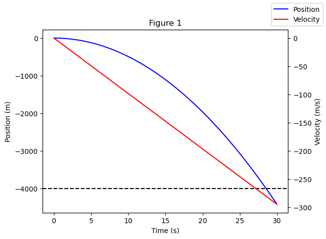

```python
# Part 3
# Initialize variables
alpha = 0
gamma = 2
v0 = 0
y0 = 0
t0 = 0
tf = 30
tt = np.linspace(t0, tf, 1000)


# Create event function
def hit_bottom(t, Y, g_0, alpha, gamma):
    v, y = Y
    return height + y


# Numerically solve (1) using solve_ivp() assuming alpha = 0
soln = solve_ivp(fun = free_fall, t_span = (t0, tf), y0 = [v0, y0], args = (g_0, alpha, gamma), t_eval = tt, events = hit_bottom)
t = soln.t
v = soln.y[0]
y = soln.y[1]


# Plot the position and velocity as a function of time
fig, ax = plt.subplots()
ax2 = ax.twinx()
ax.plot(t, y, color = "blue", label = "Position")
ax2.plot(t, v, color = "red", label = "Velocity")
ax.axhline(-height, color = "black", linestyle = "dashed")
ax.set_title("Figure 1")
ax.set_xlabel("Time (s)")
ax.set_ylabel("Position (m)")
ax2.set_ylabel("Velocity (m/s)")
fig.legend();
```

```python
# Part 4
# Calculate the time at which the mass hits the bottom of the shaft in the case of zero drag
t_hit = soln.t_events[0][0]
print(f"Bottom hit: {t_hit:.2f} s")
```

```
Bottom hit: 28.56 s
```

## Part 2: Including Drag and a Variable g

In practice, we cannot ignore drag, and we should also not assume that $g$ is a constant. If you approximate that the mass of the Earth is distributed homogenously (which it is not!), then the gravitational constant $g$ will depend on your distance $r$ from the center of the Earth in a simple linear way:

$$ g(r) = g_o \left( \frac{r}{R_{\oplus}} \right) \tag{2} $$

where $g_o$ is the gravity at the surface, and $R_{\oplus}$ is the radius of the Earth.

1. Make a new plot that shows the velocity and position as a function of  
   time assuming $g(y)$. Be careful with coordinate systems! The test mass' position should be at the Earth radius at $t=0$, and falling down. But for plotting purposes, it will be useful to plot the height above the bottom of the shaft.  
   In your notebook, label this figure clearly as **Figure 2**.
2. What effect does incorporating a height-dependent $g$ have on the fall time? Explain.
3. Now, turn on drag, and replot the position and velocity. For most things, $\gamma=2$ is a good assumption. How can you calibrate the value of $\alpha$? Think about what we did in Lecture 15/16, where we assumed a sky-diver's terminal speed was 50 m/s. You should assume the same of the test mass. What affect does including drag have on the fall time?

```
Bottom hit: 83.54 s
```

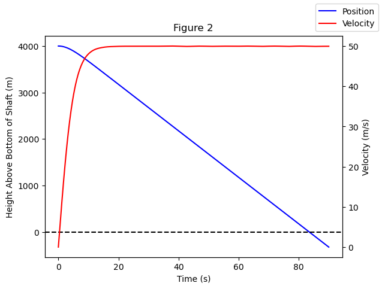

```python
# Part 1
# Adjust time array
t0 = 0
tf = 90
tt = np.linspace(t0, tf, 1000)


# Part 2
# Calibrate drag coefficient
gamma = 2
v_f = 50
alpha = (mass * g_0) / (v_f**gamma)


# Gravity inside Earth
def grav_Earth(y):
    r = R_E - y
    return g_0 * (r / R_E)


# Coupled first order differential equations
def grav_fall(t, Y):
    v, y = Y
    dydt = v
    # Part 1
    # dvdt = grav_Earth(y)
    # Part 3
    dvdt = grav_Earth(y) - ((alpha) * ((np.abs(v))**gamma))
    return [dvdt, dydt]


# Event: stop at bottom of shaft
def hit_bottom(t, Y):
    v, y = Y
    return y - height


# Solve system
soln = solve_ivp(grav_fall, t_span = (t0, tf), y0 = [v0, y0], t_eval = tt, events = hit_bottom)


# Extract results
t = soln.t
v = soln.y[0]
y = soln.y[1]


# Height above the bottom of the shaft
height_from_bottom = height - y


# Plot everything
fig, ax = plt.subplots()
ax2 = ax.twinx()
ax.plot(t, height_from_bottom, color = "blue", label = "Position")
ax2.plot(t, v, color = "red", label = "Velocity")
ax.axhline(0, color = "black", linestyle = "dashed")
ax.set_title("Figure 2")
ax.set_xlabel("Time (s)")
ax.set_ylabel("Height Above Bottom of Shaft (m)")
ax2.set_ylabel("Velocity (m/s)")
fig.legend();


# Calculate the time at which the mass hits the bottom of the shaft in the case of variable gravity
t_hit = soln.t_events[0][0]
print(f"Bottom hit: {t_hit:.2f} s")
```

**Part 2.3**  
Including drag significantly increases the amount of time it takes for the mass to hit the bottom of the shaft. This is because the drag force is working against gravity, thus slowing down its movement through the shaft.

## Part 3: The Coriolis Force

Since the Earth is rotating, there is a Coriolis force on the test mass as it falls. The force can be quite large. For example, imagine the mine shaft is on the Earth's equator and pointed towards the Earth's center. The equator rotates at about half a kilometer per second. So once the test mass has fallen for some time, it will bump into the wall, unless the shaft is very wide. The Coriolis force $\vec{F_c}$ is:

$$ \vec{F_c} = -2m \, \left( \vec{\Omega} \times \vec{v} \right) \tag{3} $$

where $\vec{\Omega}$ is the Earth's rotation rate for a vector along $\hat{z}$ and $m$ is the mass of the object (1 kg for the test mass in this case). For a mine shaft on the equator, we might pick a right-handed coordinate system with the $\hat{x}$ axis along the East, $\hat{y}$ down into the mine shaft, and $\hat{z}$ along the North. This implies the component of the force are:

\begin{equation} F_{c_x} = + 2m \, \Omega v_y \tag{4} \end{equation} \begin{equation} F_{c_y} = - 2m \, \Omega v_x \tag{5} \end{equation} \begin{equation} F_{c_z} = 0 \tag{6} \end{equation}

1. Extend and update your differential equations of motion to include the Coriolis force. You will need to add a Coriolis acceleration term to your equation for the depth coordinate (remember, $F=ma$), and additionally, start tracking the velocity and position in the transverse direction (``side-to-side'' in the shaft).
2. Plot the transverse position of the object as a function of depth, initially assuming $\alpha=0$. That is, both axes will have units of distance. Plot ``dots" every few seconds so that you can see how the particle moves over time. Note that your depth and transverse axes are likely to have very different length scales. The depth will have a range of 4 km, while the transverse direction is about 5m.  
   In your report, this should be **Figure 3**.
3. If the mine shaft is 5m wide, and you drop the test mass from the center, does the test mass reach the bottom? Or does it bump into the wall first?
4. Now turn drag back on. Does drag make any difference here?

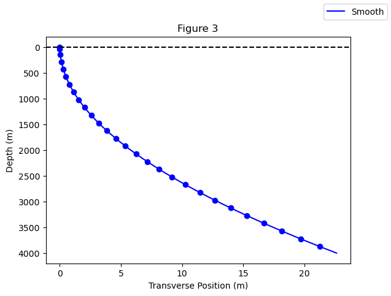

```python
# Part 3
# Adjust time array
t0 = 0
tf = 200
tt = np.linspace(t0, tf, 1000)


# Constants
omega = 2 * np.pi / (24 * 60 * 60)    # rad/s

def grav_Earth(y):
    r = R_E - y
    return g_0 * (r / R_E)


def coriolis(t, Y):
    x, y, vx, vy = Y

    dxdt = vx
    dydt = vy

    # Acceleration due to the Coriolis effect
    ax_coriolis = 2 * omega * vy
    ay_coriolis = 2 * omega * vx

    # Acceleration due to the drag force
    ax_drag = -alpha * np.abs(vx)**(gamma - 1) * vx
    ay_drag = -alpha * np.abs(vy)**(gamma - 1) * vy

    dvxdt = ax_coriolis + ax_drag
    dvydt = grav_Earth(y) + ay_coriolis + ay_drag

    return [dxdt, dydt, dvxdt, dvydt]


# Event: stop at bottom of shaft
def hit_bottom(t, Y):
    x, y, vx, vy = Y
    return y - height

Y0 = [0, 0, 0, 0]

# Solve system
soln = solve_ivp(coriolis, t_span = (t0, tf), y0 = Y0, t_eval = tt, events = hit_bottom)


# Extract results
t = soln.t
t_hit = soln.t_events[0][0]


# Create smooth curve
t_plot = np.linspace(0, t_hit, 1000)
soln = solve_ivp(coriolis, t_span = (t0, t_hit), y0 = Y0, t_eval = t_plot, events = hit_bottom)

x = soln.y[0]
y = soln.y[1]
vx = soln.y[2]
vy = soln.y[3]


# Create points for dots
t_dots = np.arange(0, t_hit, 3)
soln = solve_ivp(coriolis, t_span = (t0, t_hit), y0 = Y0, t_eval = t_dots, events = hit_bottom)
x_dots, y_dots, vx_dots, vy_dots = soln.y


# Part 2
# Plot everything
fig, ax = plt.subplots()
ax.plot(x, y, color = "blue", label = "Smooth")
ax.plot(x_dots, y_dots, "bo")
ax.axhline(0, color = "black", linestyle = "dashed")
ax.set_title("Figure 3")
ax.set_ylabel("Depth (m)")
ax.set_xlabel("Transverse Position (m)")
ax.invert_yaxis()

fig.legend();
```

**Part 3.3**  
Since the mass will travel more than 5 meters transversally, which is greater than the width of the shaft is 5 meters wide, the mass will bump into the wall first before it reaches the bottom.

## Part 4: An infinitely deep mine

Now, let us consider the theoretical case of an infinitely deep mine -- that is, a tunnel which traverses the full diameter of the Earth. For convenience, imagine the tunnel goes from pole-to-pole, such that $\vec{\Omega} \times \vec{v} = 0$, and the Coriolis force can be neglected, as well as the drag force.

Additionally, continue assuming a constant density Earth.

1. Again, plot the depth and velocity as a function of time. (Be careful with the meaning of $y$, as the particle can theoretically traverse fully through to the other side of the Earth.) Comment on what you see in the graph.  
   In your notebook, label this figure clearly as **Figure 4**.
2. How long will it take for the object to reach the other side? At what time does the object reach the center of the Earth, and at what speed?
3. How does this ``crossing-time" compare to the orbital period, where you assume the object is on a circular orbit, in centripetal balance with the attractive force of the gravity. \begin{equation} \frac{v^2}{R} = \frac{GM}{R^2} \tag{7} \end{equation} gives the orbital speed $v$ for a given Earth radius $R$ and Earth mass $M$.

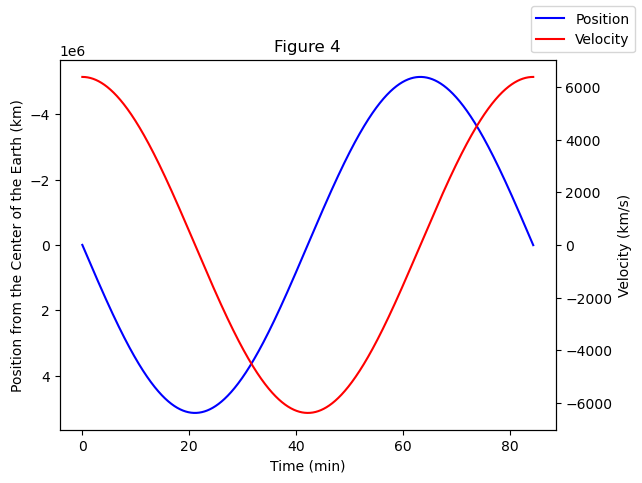

```python
# Part 1
# Adjust time array - estimate period for SHO
omega = np.sqrt(g_0 / R_E)
period = 2 * np.pi / omega

# Solve for a little more than one full oscillation
t0 = 0
tf = period
tt = np.linspace(t0, tf, 2000)


# Gravity inside Earth
def grav_Earth(y):
    return -g_0 * (y / R_E)


def infinite(t, Y):
    v, y = Y
    dydt = v
    dvdt = grav_Earth(y)
    return [dvdt, dydt]


Y0 = [R_E, 0]


# Solve system
soln = solve_ivp(infinite, t_span = (t0, tf), y0 = Y0, t_eval = tt)


# Extract results
t = soln.t
v = soln.y[0]
y = soln.y[1]

t = t / 60    # Convert to minutes
v = v / 1000    # Convert to km/s
y = y / 1000    # Convert to km


# Plot everything
fig, ax = plt.subplots()
ax2 = ax.twinx()
ax.plot(t, y, color = "blue", label = "Position")
ax2.plot(t, v, color = "red", label = "Velocity")
ax.set_title("Figure 4")
ax.set_ylabel("Position from the Center of the Earth (km)")
ax2.set_ylabel("Velocity (km/s)")
ax.set_xlabel("Time (min)")
ax.invert_yaxis()

fig.legend();
```

**Part 4.1**  
The mass moves in oscillations.

```python
# Part 2
# Calculate time to reach the other side
t_other_side = period / 2
t_other_side = t_other_side / 60    # Convert to minutes
print(f"4.2. The mass will take {t_other_side:.2f} minutes to reach the other side.")


# Calculate time to reach the center of the Earth
t_center = t_other_side / 2
print(f"The mass will take {t_center:.2f} minutes to reach the center of the Earth.")


# Calculate the velocity at the time when the mass reaches the center of the Earth
v_center = np.sqrt(g_0 * R_E)
v_center = v_center / (10**3)    # Convert to km
print(f"The velocity of the mass at the time when it reaches the center of the Earth is {v_center:.2f} km/s")
```

[output not shown]

```python
# Part 3
# Calculate the orbital velocity
v_orbit = np.sqrt((g_0 * R_E**2) / R_E)


# Calculate the period of a circular orbit
T_orbit = (2 * np.pi * R_E) / v_orbit / 60    # Convert to minutes


# Calculate the time at which the mass would reach the center of the Earth in a circular orbit
t_cross = T_orbit / 2


# Print results
print(f"Calculated values: orbital velocity = {v_orbit:.2f} m/s, orbital period = {T_orbit:.2f} min, cross-time = {t_cross:.2f} min")
```

```
Calculated values: orbital velocity = 7910.07 m/s, orbital period = 84.44 min, cross-time = 42.22 min
```

## Part 5: A non-uniform Earth

Finally, let us consider the case of a non-uniform Earth, and continue assuming we have no drag. We know from geology that the density increases towards the center. It rises from about 2-3 g/cm$^3$ near the surface, to more like 13 near the center. A simple model for the density $\rho$ as a function of distance from the center of the Earth $r$ is:

$$ \rho(r) = \rho_n \left( 1 - \frac{r^2}{R_{\oplus}^2} \right)^n \tag{8} $$

where $n$ is some exponent, and $\rho_n$ is a normalizing constant. The case of $n=0$ is the constant density Earth, while $n=2$ is closer to the real value. Note that the total mass of the Earth, $M$, must be conserved. Since the mass is the volume integral over the density:

\begin{equation} M = \int_V \rho(r) dV = \int_0^{2\pi} \int_0^{\pi} \int_0^{R_{\oplus}} \rho(r) r^2 \sin \phi \, dr \, d\phi \,d\theta = 4 \pi \int_0^{R_{\oplus}} \rho(r) r^2 \, dr \tag{9} \end{equation}

you will need to recompute the density constant $\rho_n$ for each case of $n>0$, You can use the `quad` integrator for this. Note that the analytic solution is straightforward to do by hand for $n=0$, and still manageable for $n=1,2$. You might consider doing that integral to make sure your method is right, and then you can be confident for $n>0$.

1. Plot the normalized density profile (that is, set $\rho_n=1$) as a function of radius for $n=0, 1, 2, 9$.  
   Put them all on the same plot, with a clear legend.  
   In your notebook, label this figure clearly as **Figure 5**.
2. Now, plot the force profile as a function of radius for $n=0, 1, 2, 9$.  
   This step will show you if your normalization factor $\rho_n$ is correct, because the surface force must be the same for all $n$.  
   In your notebook, label this figure clearly as **Figure 6**.
3. Then, plot the position and velocity as a function of time for $n=0, 1, 2, 9$ as you did in Figure 1/2.  
   In your notebook, label this figure clearly as **Figure 7**.
4. For $n=0, 1, 2, 9$, compute the time to reach the center, and the speed achieved there.

### Part 5, Section A (Density)

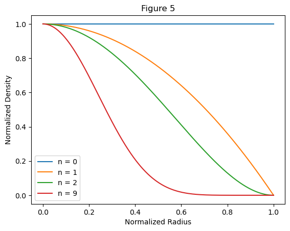

```python
# Part 5, Section A
# No drag
# Create array for radius values
rr = np.linspace(0, R_E, 1000)


# Initialize array with n-values to plot
n_values = [0, 1, 2, 9]

# Plot everything
fig, ax = plt.subplots()


# Normalize densities
for n in n_values:
    dens_normalized = (1 - (rr**2 / (R_E**2)))**n
    ax.plot(rr / R_E, dens_normalized, label = f"n = {n}")

ax.set_xlabel("Normalized Radius")
ax.set_ylabel("Normalized Density")
ax.set_title("Figure 5")
ax.legend();
```

### Part 5, Section B (Forces)

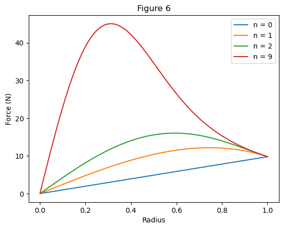

```python
# Part 5, Section B
# Plot the force profile as a function of radius for n = 0, 1, 2, 9
from scipy.integrate import quad


# Create density normalization function
def normalize(r, n):
    dens_normalized = (1 - (r**2 / (R_E**2)))**n
    return dens_normalized


# Plot everything
fig, ax = plt.subplots()

for n in n_values:

    total_integral, _ = quad(lambda r: normalize(r, n) * (r**2), 0, R_E)
    dens_n = M_E / (4 * np.pi * total_integral)
    forces = []

    for r in rr:
        enclosed_integral, _ = quad(lambda rp: dens_n * normalize(rp, n) * (rp**2), 0, r)
        M_enc = 4 * np.pi * enclosed_integral

        force = (G * M_enc) / (r**2)
        forces.append(force)

    ax.plot(rr / R_E, forces, label = f"n = {n}")

ax.set_title("Figure 6")
ax.set_xlabel("Radius")
ax.set_ylabel("Force (N)")
ax.legend()
```

### Part 5, Section C (Equations of Motion)

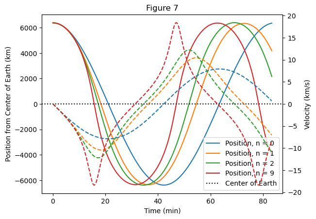

```python
# Part 5, Section C
# Plot the position and velocity as a function of time for n = 0, 1, 2, 9
from scipy.interpolate import interp1d


# Adjust time array
t0 = 0
tf = 5000
tt = np.linspace(t0, tf, 2500)


def normalize(r, n):
    return (1 - r**2 / R_E**2)**n


def dens_norm(n):
    integral, _ = quad(lambda r: normalize(r, n) * r**2, 0, R_E)
    return M_E / (4 * np.pi * integral)


def enclosed_mass(r, n, dens_norm):
    integral, _ = quad(lambda rp: dens_norm * normalize(rp, n) * rp**2, 0, r)
    return 4 * np.pi * integral


def reach_center(t, Y):
    y, v = Y
    return y


# Plot everything
fig, ax = plt.subplots()
ax2 = ax.twinx()
t_events = []
v_events = []

for n in n_values:
    dens_n = dens_norm(n)

    rr = np.linspace(1, R_E, 1000)
    aa = []

    for r in rr:
        M_enc = enclosed_mass(r, n, dens_n)
        a = (G * M_enc) / (r**2)
        aa.append(a)

    a_grid = np.array(aa)


    # Interpolation function for acceleration magnitude
    a_mag = interp1d(rr, aa, kind = "cubic", fill_value = "extrapolate")


    # Coupled equations
    def deriv(t, Y):
        y, v = Y
        r = abs(y)

        # Acceleration points toward center
        if y > 0:
            a = -a_mag(r)
        elif y < 0:
            a = a_mag(r)
        else:
            a = 0

        return [v, a]

    soln = solve_ivp(deriv, (0, tf), [R_E, 0], t_eval = tt, events = reach_center)


    t = soln.t
    y = soln.y[0]
    v = soln.y[1]

    t_center = soln.t_events[0][0]
    v_center = soln.y_events[0][0][1]
    t_events.append(t_center)
    v_events.append(v_center)

    ax.plot(t / 60, y / 1000, label = f"Position, n = {n}")
    ax2.plot(t / 60, v / 1000, linestyle = "--", label = f"Velocity, n = {n}")

ax.set_title("Figure 7")
ax.set_xlabel("Time (min)")
ax.set_ylabel("Position from Center of Earth (km)")
ax2.set_ylabel("Velocity (km/s)")

ax.axhline(0, color = "black", linestyle = "dotted", label = "Center of Earth")
ax.legend();
```

```python
# Part 5, Section D
# For n = 0, 1, 2, 9, compute the time to reach the center & the speed achieved there
n = [0, 1, 2, 9]
for i in range(4):
    print(f"n = {n[i]}: t = {t_events[i]:.2f} s, v = {v_events[i]:.2f} m/s")
```

```
n = 0: t = 1267.24 s, v = -7905.97 m/s
n = 1: t = 1096.89 s, v = -10435.24 m/s
n = 2: t = 1035.14 s, v = -12200.75 m/s
n = 9: t = 943.87 s, v = -18392.00 m/s
```

## Part 6: A Lunar Mine Shaft

Finally, with all of the framework in place, consider the case where the the mine shaft is instead dug on the moon.

1. Compute the travel time to the center of the moon in case we dig a pole-to-pole mine shaft, so that we can again avoid the Coriolis force, though on the moon this force is very small. No drag force either, which is actually realistic for the moon!
2. What is the density (if you asssume a constant density) of the moon compared to that of earth?
3. How does the fall/orbit time depend on density? See if you can discover a relationship between the density and the fall time. You should think beyond strictly linear relationships.

This problem can actually be done on paper, and then you can compare the answer with that for the homogenous earth you did in Part 4.

```python
# Part 1
# Compute the surface gravity on the Moon
g_m = (G * M_m) / (R_m**2)


# Coupled equations
def deriv(t, Y):
    y, v = Y
    dydt = v
    dvdt = - (g_m / R_m) * y
    return [dydt, dvdt]


# Create event function for when the mass reaches the Moons center
def reach_center(t, Y):
    y, v = Y
    return y


# Initialize variables
Y0 = [R_m, 0]

# Solve
soln = solve_ivp(deriv, (0, 10000), Y0, events = reach_center)

t_center = soln.t_events[0][0] / 60    # Convert to minutes
v_center = soln.y_events[0][0][1]    # Convert to km/s


print(f"Time to center: {t_center:.2f} minutes")
print(f"Speed at center: {abs(v_center):.2f} km/s")
```

[output not shown]

```python
# Part 2
# Compute the constant density of the moon compared to that of Earth
def const_density(M, R):
    density = (3 * M) / (4 * np.pi * (R)**3)
    return density


dens_m = const_density(M_m, R_m)
dens_E = const_density(M_E, R_E)


print(f"Constant density of the Moon: {dens_m:.2f} kg m^-3")
print(f"Constant density of the Earth: {dens_E:.2f} kg m^-3")
print(f"Ratio: {dens_m/dens_E:.2f}")
```

```
Constant density of the Moon: 3341.75 kg m^-3
Constant density of the Earth: 5494.87 kg m^-3
Ratio: 0.61
```

```python
# Part 3
# Orbit time dependence on density
# Compute period & time to reach the center
def calc(density):
    T = 2 * np.pi * np.sqrt(3 / (4 * np.pi * G * density))
    t_center = T / 4
    return T, t_center


T_E, t_center_E = calc(dens_E)
T_m, t_center_m = calc(dens_m)


T_E, t_center_E = T_E / 60, t_center_E / 60    # Convert to minutes
T_m, t_center_m = T_m / 60, t_center_m / 60    # Convert to minutes


print(f"Earth: Period = {T_E:.2f} min, Time to Center = {t_center_E:.2f} min")
print(f"Moon: Period = {T_m:.2f} min, Time to Center = {t_center_m:.2f} min")


# Comparison ratios
period_ratio = T_m / T_E
time_to_center_ratio = t_center_m / t_center_E

print(f"Actual time ratio (Moon/Earth): {period_ratio:.2f}")
print(f"Predicted ratio from density scaling: {time_to_center_ratio:.2f}")
```

```
Earth: Period = 84.49 min, Time to Center = 21.12 min
Moon: Period = 108.34 min, Time to Center = 27.09 min
Actual time ratio (Moon/Earth): 1.28
Predicted ratio from density scaling: 1.28
```

## Part 7: Fourier Transforming Orbits

Take the solutions for n=0 and n=9 of the orbits in Part 5 (the inhomogeneous earth) and Fourier Transform them, to see what frequencies (*1/periods*) are dominant in the power spectra. Comment on what you see.

**Hint:** you could take the orbit from the previous integration in Part 5c, but it is useful to increase the integration time and sampling to get more meaningful smooth enough curves. We discussed this in class.

For an example of a spectral analysis of galactic orbits see https://articles.adsabs.harvard.edu/pdf/1982ApJ...252..308B

```
n = 0
Dominant frequency = 1.99997e-04 Hz
Dominant period = 83.33 min

n = 9
Dominant frequency = 2.66663e-04 Hz
Dominant period = 62.50 min
```

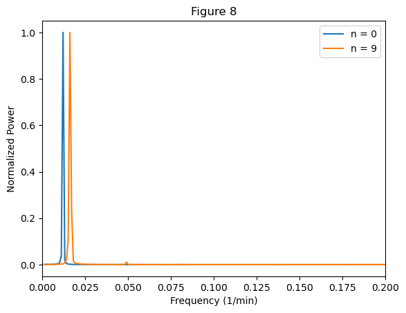

```python
# Part 7
from scipy.integrate import cumulative_trapezoid
n_values = [0, 9]


def normalize(r, n):
    return (1 - r**2 / R_E**2)**n

def make_acceleration_function(n):
    rr = np.linspace(0, R_E, 5000)

    dens_shape = normalize(rr, n)

    # Normalize density so total mass = Earth mass
    mass_integrand = dens_shape * rr**2
    total_integral = cumulative_trapezoid(mass_integrand, rr, initial = 0)[-1]
    dens_n = M_E / (4 * np.pi * total_integral)

    # Enclosed mass
    enclosed_integral = cumulative_trapezoid(dens_n * dens_shape * rr**2, rr, initial=0)

    M_enc = 4 * np.pi * enclosed_integral

    # Acceleration magnitude
    a_grid = np.zeros_like(rr)
    a_grid[1:] = G * M_enc[1:] / rr[1:]**2
    a_grid[0] = 0

    return interp1d(rr, a_grid, kind = "cubic", bounds_error = False, fill_value="extrapolate")


def solve_orbit(n, tf =60000, N = 2**16):
    a_mag = make_acceleration_function(n)

    def deriv(t, Y):
        y, v = Y
        r = abs(y)

        # Acceleration points toward center
        if y > 0:
            a = -a_mag(r)
        elif y < 0:
            a = a_mag(r)
        else:
            a = 0

        return [v, a]

    tt = np.linspace(0, tf, N)

    sol = solve_ivp(deriv, (0, tf), [R_E, 0], t_eval = tt)

    return sol.t, sol.y[0], sol.y[1]


# Fourier transform analysis
fig, ax = plt.subplots()

for n in n_values:
    t, y, v = solve_orbit(n)

    dt = t[1] - t[0]

    # Remove mean before Fourier transform
    y_centered = y - np.mean(y)

    fft_y = np.fft.rfft(y_centered)
    freqs = np.fft.rfftfreq(len(t), d=dt)

    power = np.abs(fft_y)**2

    # Ignore zero frequency
    freqs = freqs[1:]
    power = power[1:]

    # Convert frequency to 1/min for easier interpretation
    freqs_per_min = freqs * 60

    ax.plot(freqs_per_min, power / np.max(power), label = f"n = {n}")

    # Find dominant frequency
    dominant_index = np.argmax(power)
    dominant_freq = freqs[dominant_index]
    dominant_period = 1 / dominant_freq

    print(f"n = {n}")
    print(f"Dominant frequency = {dominant_freq:.5e} Hz")
    print(f"Dominant period = {dominant_period/60:.2f} min")
    print()

ax.set_xlabel("Frequency (1/min)")
ax.set_ylabel("Normalized Power")
ax.set_title("Figure 8")
ax.legend()
ax.set_xlim(0, 0.2)

plt.show()
```

Describe what we see here: